# HSI_Unet_model_3_r2

## Hyper Spectral Image Segmentation using UNET

### Overview

This is continuation of HSI segmentation case study presented in link :

https://sachinbu.medium.com/hyperspectral-image-segmentation-21432965e138

In the study simple neural network was used to classify each pixel in the Hyper Spectral Image.

As mentioned in the above article(section- Alternative Approach), we will consider Convolutional Neural Network (CNN) for HSI segmentation.

U-Net is the CNN model considered for the study. Here two types of model are trained:

1. Pretrained U-Net which has resnet as backbone for encoder section. Convolution layers are added before the pretrained Network to get a 3 channel image which will be fed to the pretrained Network.
2. Simple U-Net trained from scratch.

Same data mentioned in the above article is considered in this study.

To train the above mentioned models, Indian Pines image (145x145x200) is augmented to get 1000 images where 800 images are used for training the model and 200 images are used for validation. Details of generating the images and training the model are captured in this notebook

```python
pip install patchify
```

```python
import numpy as np
import scipy.io
import matplotlib.pyplot as plt
import patchify as patch
from sklearn.preprocessing import StandardScaler
import tensorflow as tf
import os,time
from datetime import datetime
from scipy.ndimage import rotate
```

### Data

```python
# Data Source : http://www.ehu.eus/ccwintco/index.php/Hyperspectral_Remote_Sensing_Scenes#Indian_Pines
!wget wget --header="Host: www.ehu.eus" --header="User-Agent: Mozilla/5.0 (Windows NT 10.0; Win64; x64) AppleWebKit/537.36 (KHTML, like Gecko) Chrome/97.0.4692.71 Safari/537.36" --header="Accept: text/html,application/xhtml+xml,application/xml;q=0.9,image/avif,image/webp,image/apng,*/*;q=0.8,application/signed-exchange;v=b3;q=0.9" --header="Accept-Language: en-US,en;q=0.9" --header="Referer: http://www.ehu.eus/ccwintco/index.php/Hyperspectral_Remote_Sensing_Scenes" "http://www.ehu.eus/ccwintco/uploads/6/67/Indian_pines_corrected.mat" -c -O 'Indian_pines_corrected.mat'
!unzip Indian_pines_corrected.mat
```

[output not shown]

```python
img = scipy.io.loadmat('Indian_pines_corrected.mat')['indian_pines_corrected']
img_gt = scipy.io.loadmat('Indian_pines_gt.mat')['indian_pines_gt']
```

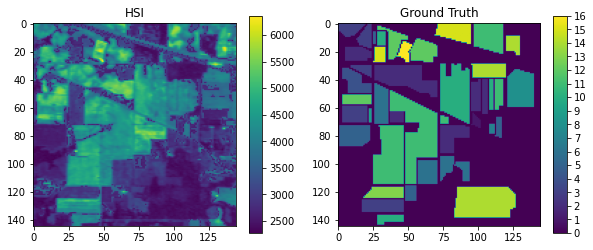

```python
figr,axis = plt.subplots(1,2,figsize=(10,10))
im0 = axis[0].imshow(img[:,:,30])#,cmap='jet')
axis[0].set_title('HSI')
plt.colorbar(im0,ax=axis[0],shrink=0.4,aspect=16)#, ticks=range(0,17,1))

im1 = axis[1].imshow(img_gt)#,cmap='jet')
axis[1].set_title('Ground Truth')
plt.colorbar(im1,ax=axis[1],shrink=0.4,aspect=16, ticks=range(0,17,1))
plt.show()
```

```python
img.shape,img_gt.shape
```

```
((145, 145, 200), (145, 145))
```

#### Data Augmentation

Generating Multiple images from available image :

- Rotating image by 90, 180 and 270 deg
- Flipping original and rotated images

```python
img_rot1 =  np.rot90(img,1)
img_gt_rot1 = np.rot90(img_gt,1)
```

```python
img_rot2 =  np.rot90(img,2)
img_gt_rot2 = np.rot90(img_gt,2)
```

```python
img_rot3 =  np.rot90(img,3)
img_gt_rot3 = np.rot90(img_gt,3)
```

```python
img_rot4 =  rotate(img,-45,reshape=False,mode ='reflect')
img_gt_rot4 =  rotate(img_gt,-45,reshape=False,mode ='reflect')
img_gt_rot4.shape
```

```
(145, 145)
```

```python
img_flip =  np.fliplr(img)
img_gt_flip = np.fliplr(img_gt)

img_rot1_fp =  np.fliplr(img_rot1)
img_gt_rot1_fp = np.fliplr(img_gt_rot1)

img_rot2_fp =  np.fliplr(img_rot2)
img_gt_rot2_fp = np.fliplr(img_gt_rot2)

img_rot3_fp =  np.fliplr(img_rot3)
img_gt_rot3_fp = np.fliplr(img_gt_rot3)

img_rot4_fp =  np.fliplr(img_rot4)
img_gt_rot4_fp = np.fliplr(img_gt_rot4)
```

#### Generating Patches of size 64 x 64 from the augmented images

```python
# image patches of the Augmented Hyperspectral images
img_patches        = np.squeeze(patch.patchify(img,      (64, 64,200) , step=9), axis=2)
img_r1_patches     = np.squeeze(patch.patchify(img_rot1, (64, 64,200) , step=9), axis=2)
img_r2_patches     = np.squeeze(patch.patchify(img_rot2, (64, 64,200) , step=9), axis=2)
img_r3_patches     = np.squeeze(patch.patchify(img_rot3, (64, 64,200) , step=9), axis=2)
img_r4_patches     = np.squeeze(patch.patchify(img_rot4, (64, 64,200) , step=9), axis=2)

img_fp_patches     = np.squeeze(patch.patchify(img_flip,    (64, 64,200) , step=9), axis=2)
img_r1_fp_patches  = np.squeeze(patch.patchify(img_rot1_fp, (64, 64,200) , step=9), axis=2)
img_r2_fp_patches  = np.squeeze(patch.patchify(img_rot2_fp, (64, 64,200) , step=9), axis=2)
img_r3_fp_patches  = np.squeeze(patch.patchify(img_rot3_fp, (64, 64,200) , step=9), axis=2)
img_r4_fp_patches  = np.squeeze(patch.patchify(img_rot4_fp, (64, 64,200) , step=9), axis=2)
```

```python
# image patches of the Augmented Ground Truths of Hyperspectral images
img_gt_patches        = patch.patchify(img_gt,      (64, 64), step=9)
img_gt_r1_patches     = patch.patchify(img_gt_rot1, (64, 64), step=9)
img_gt_r2_patches     = patch.patchify(img_gt_rot2, (64, 64), step=9)
img_gt_r3_patches     = patch.patchify(img_gt_rot3, (64, 64), step=9)
img_gt_r4_patches     = patch.patchify(img_gt_rot4, (64, 64), step=9)

img_gt_fp_patches     = patch.patchify(img_gt,         (64, 64), step=9)
img_gt_r1_fp_patches  = patch.patchify(img_gt_rot1_fp, (64, 64), step=9)
img_gt_r2_fp_patches  = patch.patchify(img_gt_rot2_fp, (64, 64), step=9)
img_gt_r3_fp_patches  = patch.patchify(img_gt_rot3_fp, (64, 64), step=9)
img_gt_r4_fp_patches  = patch.patchify(img_gt_rot4_fp, (64, 64), step=9)
```

```python
img_r4_patches.shape, img_gt_r4_patches.shape
```

```
((10, 10, 64, 64, 200), (10, 10, 64, 64))
```

```python
img_r1_fp_patches.shape
```

```
(10, 10, 64, 64, 200)
```

```python
img_patches[5][5][:,:,20].shape
```

```
(64, 64)
```

```python
# img_patches = np.squeeze(img_patches, axis=2)#.shape
```

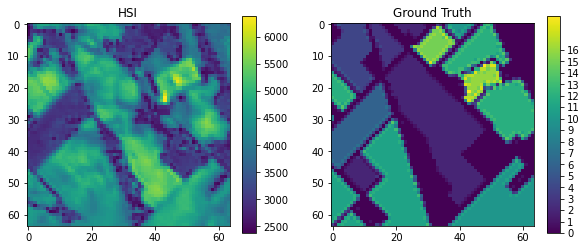

```python
# Verifying the augmented data
figr,axis = plt.subplots(1,2,figsize=(10,10))
im0 = axis[0].imshow(img_r4_patches[0][5][:,:,30])#,cmap='jet')
axis[0].set_title('HSI')
plt.colorbar(im0,ax=axis[0],shrink=0.4,aspect=16)#, ticks=range(0,17,1))

im1 = axis[1].imshow(img_gt_r4_patches[0][5])#,cmap='jet')
axis[1].set_title('Ground Truth')
plt.colorbar(im1,ax=axis[1],shrink=0.4,aspect=16, ticks=range(0,17,1))
# plt.savefig('NeuNet_3_e100.png')
plt.show()
```

#### Storing images

data are stored in *.mat files (for reuse - to avoid running the augmentation everytime data is required)

```python
# HSI - collection of augmented patches
HSI_AUGM_mat1 = dict()
HSI_AUGM_mat1['img_orig'] = img_patches
scipy.io.savemat('Indian_pines_HSI_AUGM_1.mat',HSI_AUGM_mat1)

HSI_AUGM_mat2 = dict()
HSI_AUGM_mat2['img_rot1'] = img_r1_patches
scipy.io.savemat('Indian_pines_HSI_AUGM_2.mat',HSI_AUGM_mat2)

HSI_AUGM_mat3 = dict()
HSI_AUGM_mat3['img_rot2'] = img_r2_patches
scipy.io.savemat('Indian_pines_HSI_AUGM_3.mat',HSI_AUGM_mat3)

HSI_AUGM_mat4 = dict()
HSI_AUGM_mat4['img_rot3'] = img_r3_patches
scipy.io.savemat('Indian_pines_HSI_AUGM_4.mat',HSI_AUGM_mat4)

HSI_AUGM_mat5 = dict()
HSI_AUGM_mat5['img_rot4'] = img_r4_patches
scipy.io.savemat('Indian_pines_HSI_AUGM_5.mat',HSI_AUGM_mat5)

HSI_AUGM_mat6 = dict()
HSI_AUGM_mat6['img_flp0'] = img_fp_patches
scipy.io.savemat('Indian_pines_HSI_AUGM_6.mat',HSI_AUGM_mat6)

HSI_AUGM_mat7 = dict()
HSI_AUGM_mat7['img_flp1'] = img_r1_fp_patches
scipy.io.savemat('Indian_pines_HSI_AUGM_7.mat',HSI_AUGM_mat7)

HSI_AUGM_mat8 = dict()
HSI_AUGM_mat8['img_flp2'] = img_r2_fp_patches
scipy.io.savemat('Indian_pines_HSI_AUGM_8.mat',HSI_AUGM_mat8)

HSI_AUGM_mat9 = dict()
HSI_AUGM_mat9['img_flp3'] = img_r3_fp_patches
scipy.io.savemat('Indian_pines_HSI_AUGM_9.mat',HSI_AUGM_mat9)

HSI_AUGM_mat10 = dict()
HSI_AUGM_mat10['img_flp4'] = img_r4_fp_patches
scipy.io.savemat('Indian_pines_HSI_AUGM_10.mat',HSI_AUGM_mat10)
```

```python
# Ground Truth patches
HSI_AUGM_GT_mat = dict()
HSI_AUGM_GT_mat['gt_orig']  = img_gt_patches
HSI_AUGM_GT_mat['gt_rot1']  = img_gt_r1_patches
HSI_AUGM_GT_mat['gt_rot2']  = img_gt_r2_patches
HSI_AUGM_GT_mat['gt_rot3']  = img_gt_r3_patches
HSI_AUGM_GT_mat['gt_rot4']  = img_gt_r4_patches
HSI_AUGM_GT_mat['gt_flp0']  = img_gt_fp_patches
HSI_AUGM_GT_mat['gt_flp1']  = img_gt_r1_fp_patches
HSI_AUGM_GT_mat['gt_flp2']  = img_gt_r2_fp_patches
HSI_AUGM_GT_mat['gt_flp3']  = img_gt_r3_fp_patches
HSI_AUGM_GT_mat['gt_flp4'] =  img_gt_r4_fp_patches
scipy.io.savemat('Indian_pines_HSI_AUGM_GT.mat',HSI_AUGM_GT_mat)
```

### Data Loader for model

```python
!wget --header="Host: doc-08-9k-docs.googleusercontent.com" --header="User-Agent: Mozilla/5.0 (Windows NT 10.0; Win64; x64) AppleWebKit/537.36 (KHTML, like Gecko) Chrome/98.0.4758.102 Safari/537.36" --header="Accept: text/html,application/xhtml+xml,application/xml;q=0.9,image/avif,image/webp,image/apng,*/*;q=0.8,application/signed-exchange;v=b3;q=0.9" --header="Accept-Language: en-US,en;q=0.9" --header="Cookie: AUTH_82jcsesreiehjbhkrct3c4mrj1raokod_nonce=q8gh1ahtf4f6a" --header="Connection: keep-alive" "https://doc-08-9k-docs.googleusercontent.com/docs/securesc/rg90kivf62vcrm9d2s7vb24hsj0c3fo2/l07odngss28mjnkteaojfea7h3m8qjtv/1646371125000/00176583124175523585/00176583124175523585/1x4XcTWHS3r7XAJgDRYaeYqk6xs_MAzut?e=download&ax=ACxEAsYzzyM7hHiUKXw0srY_rRqK7tk9Q9dScX24kqpjjUIzC02aIf-qn_qrOjGrCkGqP2w7b2ALJiFs339Ng4_wVB4gsrnxjmXED7dGfpx4kLIISogAwiYTcLyR4L5lanaansoSCWhmpX-fMu-FKbllv3XmyWODw09YSRauDh5BduTD23Ntoj458saACTXhDoK0BFfdLwVY8skWQvqdpl-pqmL0xeXuvUingN_XwEmlplEjdm12jLEZwC2i66CTEAlynV9MQ3-PPNWAY53w9zbYTvthGHQDwE19hjvAwc4i1D4nsGBxjZzYMMNOPopYbriZ3DWHNe64hEDqO8fNioUwxN9jfyKYylszgHCAhgh0PnDxkH2b1gjp69CmunBLKPAQhD5mojKGsXdvbzGtisM4S6xapHDo1G0HaT8SHhkbVdZxw6zIu0VWkORu1JE-AFrzigsi00qbigTEuqreDpBfs-HE-TIYsLC70yPUCkkwu5XYuITb4XHlG3U_agU4oWAUkCMBThmKi1O21UTwkMbv6dHR6zxh35z8ajWcKZtpdL7QCk037tqDBKhYAMtMHcz33mU1ZTX-ZLL2fr7zvPxgrcKdQs5Cj_ehijr4RARZ10WKVIzR_NhcJN8D7281B2RnOtnNz3R9Fmmna58pn5quOD0VIouSTZmrmYNHbSBZ&authuser=0&nonce=q8gh1ahtf4f6a&user=00176583124175523585&hash=08tleqn6p734fp3mo0ird8m361qnvetv" -c -O 'Indian_pines_HSI_AUGM_1to10.zip'
!unzip Indian_pines_HSI_AUGM_1to10.zip
```

```
--2022-03-04 05:19:10--  https://doc-08-9k-docs.googleusercontent.com/docs/securesc/rg90kivf62vcrm9d2s7vb24hsj0c3fo2/l07odngss28mjnkteaojfea7h3m8qjtv/1646371125000/00176583124175523585/00176583124175523585/1x4XcTWHS3r7XAJgDRYaeYqk6xs_MAzut?e=download&ax=ACxEAsYzzyM7hHiUKXw0srY_rRqK7tk9Q9dScX24kqpjjU…
Resolving doc-08-9k-docs.googleusercontent.com (doc-08-9k-docs.googleusercontent.com)... 142.251.6.132, 2607:f8b0:4001:c5a::84
Connecting to doc-08-9k-docs.googleusercontent.com (doc-08-9k-docs.googleusercontent.com)|142.251.6.132|:443... connected.
HTTP request sent, awaiting response... 200 OK
Length: 412730136 (394M) [application/x-zip-compressed]
Saving to: ‘Indian_pines_HSI_AUGM_1to10.zip’

Indian_pines_HSI_AU 100%[===================>] 393.61M   124MB/s    in 3.3s

2022-03-04 05:19:14 (120 MB/s) - ‘Indian_pines_HSI_AUGM_1to10.zip’ saved [412730136/412730136]

Archive:  Indian_pines_HSI_AUGM_1to10.zip
  inflating: Indian_pines_HSI_AUGM_1.mat
  inflating: Indian_pines_HSI_AUGM_10.mat
  inflating: Indian_pines_HSI_AUGM_2.mat
  inflating: Indian_pines_HSI_AUGM_3.mat
  inflating: Indian_pines_HSI_AUGM_4.mat
  inflating: Indian_pines_HSI_AUGM_5.mat
  inflating: Indian_pines_HSI_AUGM_6.mat
  inflating: Indian_pines_HSI_AUGM_7.mat
  inflating: Indian_pines_HSI_AUGM_8.mat
  inflating: Indian_pines_HSI_AUGM_9.mat
```

#### Loading the data from *.mat files

The *.mat file data are read and stored in variable.

```python
HSI_AUGM_1  = scipy.io.loadmat('Indian_pines_HSI_AUGM_1.mat')['img_orig']
HSI_AUGM_2  = scipy.io.loadmat('Indian_pines_HSI_AUGM_2.mat')['img_rot1']
HSI_AUGM_3  = scipy.io.loadmat('Indian_pines_HSI_AUGM_3.mat')['img_rot2']
HSI_AUGM_4  = scipy.io.loadmat('Indian_pines_HSI_AUGM_4.mat')['img_rot3']
HSI_AUGM_5  = scipy.io.loadmat('Indian_pines_HSI_AUGM_5.mat')['img_rot4']
HSI_AUGM_6  = scipy.io.loadmat('Indian_pines_HSI_AUGM_6.mat')['img_flp0']
HSI_AUGM_7  = scipy.io.loadmat('Indian_pines_HSI_AUGM_7.mat')['img_flp1']
HSI_AUGM_8  = scipy.io.loadmat('Indian_pines_HSI_AUGM_8.mat')['img_flp2']
HSI_AUGM_9  = scipy.io.loadmat('Indian_pines_HSI_AUGM_9.mat')['img_flp3']
HSI_AUGM_10 = scipy.io.loadmat('Indian_pines_HSI_AUGM_10.mat')['img_flp4']
```

```python
# list to generate the dataset
img_patch_list = [HSI_AUGM_1,
                  HSI_AUGM_2,
                  HSI_AUGM_3,
                  HSI_AUGM_4,
                  HSI_AUGM_5,
                  HSI_AUGM_6,
                  HSI_AUGM_7,
                  HSI_AUGM_8,
                  HSI_AUGM_9,
                  HSI_AUGM_10]
```

```python
HSI_AUGM_1.shape
```

```
(10, 10, 64, 64, 200)
```

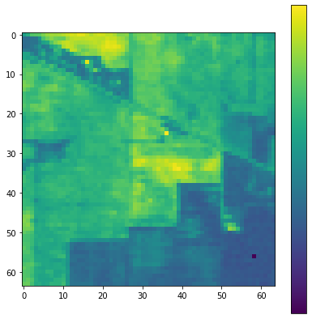

```python
# Example plot
plt.figure(figsize=(7,7))
plt.imshow(HSI_AUGM_1[5][5][:,:,10])
plt.colorbar(ticks=range(0,17))
plt.show()
```

```python
HSI_GT_AUGM_mat = scipy.io.loadmat('Indian_pines_HSI_AUGM_GT.mat')
```

```python
list(HSI_GT_AUGM_mat.keys())[3:]
```

```
['gt_orig',
 'gt_rot1',
 'gt_rot2',
 'gt_rot3',
 'gt_rot4',
 'gt_flp0',
 'gt_flp1',
 'gt_flp2',
 'gt_flp3',
 'gt_flp4']
```

```python
img_gt_patch_list = []
for key in list(HSI_GT_AUGM_mat.keys())[3:]:
  img_gt_patch_list.append(HSI_GT_AUGM_mat[key])
```

```python
img_gt_patch_list[1].shape
```

```
(10, 10, 64, 64)
```

```python
img.reshape(-1,img.shape[-1]).shape
```

```
(21025, 200)
```

#### Removing the bands which have high correlation(0.99) with other features

```python
# Reference for correlation feature filtering :  https://sachinbu.medium.com/hyperspectral-image-segmentation-21432965e138
corr_feat_list = [7, 8, 9, 15, 24, 27, 28, 38, 40, 41, 42, 43, 44, 45, 46, 47, 48, 49, 50, 51, 52, 58, 64, 65, 66, 67, 68, 69, 108, 109, 110, 111, 112, 113, 114, 115, 116, 117, 118, 119, 120, 121, 122, 123, 124, 125, 126, 127, 128, 129, 130, 131, 132, 133, 134, 135, 136, 137, 138, 139, 140, 141, 147, 148, 149, 151, 152, 153, 154, 155, 156, 157, 158, 159, 160, 161, 162, 163, 164, 165, 166, 167, 168, 169, 170, 171, 172, 173, 174, 175, 176, 177, 178, 179, 180, 181, 182, 183, 184, 185, 186, 187, 188, 189, 190]
```

```python
img_patch_list_new = []
for patchs in img_patch_list:
  filtered_patchs = np.delete(patchs,corr_feat_list,-1)
  img_patch_list_new.append(filtered_patchs)
```

```python
img_patch_list_new[9].shape
```

```
(10, 10, 64, 64, 95)
```

```python
# Deleting variable to make space for other data
del img_patch_list
del HSI_AUGM_1
del HSI_AUGM_2
del HSI_AUGM_3
del HSI_AUGM_4
del HSI_AUGM_5
del HSI_AUGM_6
del HSI_AUGM_7
del HSI_AUGM_8
del HSI_AUGM_9
del HSI_AUGM_10
```

#### Standardization

Standaradizing the values of the image matrix for each band

```python
# Removing 105 features before standardizing data
img_filtered = np.delete(img,corr_feat_list,-1)
```

```python
#Standardizing the data
Std_scaler = StandardScaler()
Std_scaler.fit(img_filtered.reshape(-1,img_filtered.shape[-1]))
```

```
StandardScaler()
```

#### Creating Dataset to have collection of images instead of patches

```python
# Generating Image dataset seperating the single 64x64x95 patch from patch grid (10,10,64,64,95) after standardising
image_dataset = []
for patchs in img_patch_list_new:
  for i in range(patchs.shape[0]):
    for j in range(patchs.shape[1]):
      single_patch = patchs[i][j]
      single_patch = Std_scaler.transform(single_patch.reshape(-1,single_patch.shape[-1])).reshape(single_patch.shape)
      image_dataset.append(single_patch)
```

```python
image_dataset = np.array(image_dataset)
image_dataset.shape
```

```
(1000, 64, 64, 95)
```

```python
# Generating Groundtruth dataset seperating the single 64x64 patch from patch grid (10,10,64,64)
gt_dataset = []
for patchs in img_gt_patch_list:
  for i in range(patchs.shape[0]):
    for j in range(patchs.shape[1]):
      gt_dataset.append(patchs[i][j])
```

```python
gt_dataset = np.array(gt_dataset)
gt_dataset.shape
```

```
(1000, 64, 64)
```

#### Dataset Review

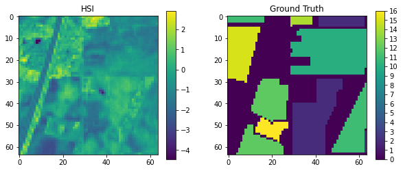

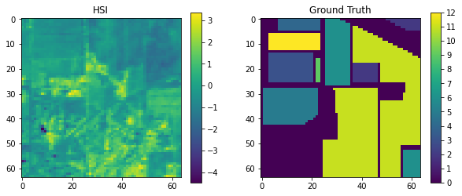

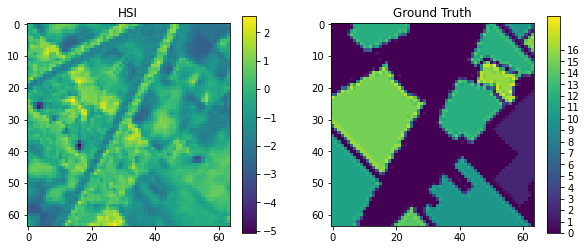

```python
for i in [150,550,900]:
  figr,axis = plt.subplots(1,2,figsize=(10,10))
  im0 = axis[0].imshow(image_dataset[i][:,:,30])#,cmap='jet')
  axis[0].set_title('HSI')
  plt.colorbar(im0,ax=axis[0],shrink=0.4,aspect=16)#, ticks=range(0,17,1))

  im1 = axis[1].imshow(gt_dataset[i])#,cmap='jet')
  axis[1].set_title('Ground Truth')
  plt.colorbar(im1,ax=axis[1],shrink=0.4,aspect=16, ticks=range(0,17,1))
  plt.show()
```

#### Data loader definition

Dataset loader used to pass data for training the model

```python
class Dataset:
  def __init__(self, images, gt_images, classes, test_set):
    ''' Dataset to have list of train/test data. image loaded upon calling __getitem__ function'''
    self.image = images
    self.gt = gt_images
    self.classes = classes # list of class label/values
    self.test_set = test_set # Boolean to differentiate train and test data

  def __getitem__(self, i):
    image = self.image[i]

    gt_image = [(self.gt[i]==c) for c in self.classes]
    gt_image = np.stack(gt_image,axis=-1).astype('float')

    return image, gt_image

  def __len__(self):
    return len(self.image)
```

```python
class Dataloder(tf.keras.utils.Sequence):
    def __init__(self, dataset, batch_size=1, shuffle=False):
        ''' This class loads data in batches while training the model'''
        self.dataset = dataset
        self.batch_size = batch_size
        self.shuffle = shuffle
        self.indexes = np.arange(len(dataset))

    def __getitem__(self, i):
        # collect batch data
        start = i * self.batch_size
        stop = (i + 1) * self.batch_size
        data = []
        for j in range(start, stop):
            data.append(self.dataset[j])

        batch = [np.stack(samples, axis=0) for samples in zip(*data)]

        return tuple(batch)

    def __len__(self):
        return len(self.indexes) // self.batch_size

    def on_epoch_end(self):
        if self.shuffle:
            self.indexes = np.random.permutation(self.indexes)
```

#### Verify the dataset class and dataloader class

```python
test = Dataset(image_dataset, gt_dataset, list(range(0,17)),0)
```

```python
ex =test.__getitem__(150)
```

```python
ex[1][:,:,10].any()
```

```
True
```

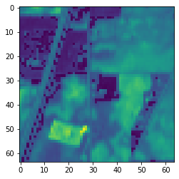

```python
plt.imshow(ex[0][:,:,15])
plt.show()
```

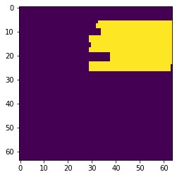

```python
plt.imshow(ex[1][:,:,10])
plt.show()
```

```python
loader = Dataloder(test, batch_size=5, shuffle=False)
```

```python
test_batch = loader.__getitem__(50)
```

```python
test_batch[0].shape,test_batch[1].shape
```

```
((5, 64, 64, 95), (5, 64, 64, 17))
```

#### Train and Test split of data

Data are split into 80% train and 20% test

```python
from sklearn.model_selection import train_test_split
X = image_dataset
y = gt_dataset

X_train, X_test, y_train, y_test = train_test_split(X, y, test_size=0.2, random_state=30)
```

```python
X_train.shape, X_test.shape,  y_train.shape, y_test.shape
```

```
((800, 64, 64, 95), (200, 64, 64, 95), (800, 64, 64), (200, 64, 64))
```

#### Dataset generation

```python
# Dataset for train images
CLASSES = list(range(17))

train_dataset = Dataset(X_train,y_train, classes=CLASSES,test_set = 0)
test_dataset  = Dataset(X_test,y_test, classes=CLASSES,test_set = 1)

BATCH_SIZE=10
train_dataloader = Dataloder(train_dataset, batch_size=BATCH_SIZE, shuffle=True)
test_dataloader = Dataloder(test_dataset, batch_size=BATCH_SIZE, shuffle=True)

print('train_dataloader image size :',train_dataloader[0][0].shape)
print('train_dataloader ground truth size :',train_dataloader[0][1].shape)
assert train_dataloader[0][0].shape == (BATCH_SIZE, 64, 64, 95)
assert train_dataloader[0][1].shape == (BATCH_SIZE, 64, 64, 17)
```

```
train_dataloader image size : (10, 64, 64, 95)
train_dataloader ground truth size : (10, 64, 64, 17)
```

### Unet Models

#### Model 1 - Pretrained model

Here pretrained model is defined using segmentation_models module

##### Model Definition

```python
pip install -U segmentation-models
```

```
     |████████████████████████████████| 50 kB 5.7 MB/s
```

```python
# we are importing the pretrained unet from the segmentation models
# https://github.com/qubvel/segmentation_models
import tensorflow
import tensorflow as tf
import segmentation_models as sm
sm.set_framework('tf.keras')
from segmentation_models import Unet
from tensorflow.keras.layers import Input,Conv2D,MaxPooling2D,Conv2DTranspose,concatenate,Cropping2D,ZeroPadding2D
from tensorflow.keras.models import Model
from segmentation_models.metrics import iou_score
from tensorflow.keras.callbacks import EarlyStopping, ModelCheckpoint,TensorBoard,ReduceLROnPlateau
tensorflow.keras.backend.set_image_data_format('channels_last')
```

```
Segmentation Models: using `keras` framework.
```

```python
# del unet_m1
```

```python
# loading the unet model and using the resnet 34 and initilized weights with imagenet weights
# "classes" :different types of classes in the dataset

base_model = Unet('resnet34', encoder_weights='imagenet', classes=17, activation='softmax', input_shape=(64,64,3),
             encoder_freeze = True)

inp = Input(shape=(64, 64, 95))

l1 = Conv2D(64, (1, 1))(inp)
l1 = Conv2D(32, (1, 1))(l1)
l1 = Conv2D(16, (1, 1))(l1)
l1 = Conv2D(8, (1, 1))(l1)
l1 = Conv2D(3, (1, 1))(l1)# map N channels data to 3 channels

out = base_model(l1)

unet_m1 = Model(inp, out, name=base_model.name)

unet_m1.summary()
```

```
Downloading data from https://github.com/qubvel/classification_models/releases/download/0.0.1/resnet34_imagenet_1000_no_top.h5
Model: "model_1"
_________________________________________________________________
 Layer (type)                Output Shape              Param #
=================================================================
 input_1 (InputLayer)        [(None, 64, 64, 95)]      0

 conv2d (Conv2D)             (None, 64, 64, 64)        6144

 conv2d_1 (Conv2D)           (None, 64, 64, 32)        2080

 conv2d_2 (Conv2D)           (None, 64, 64, 16)        528

 conv2d_3 (Conv2D)           (None, 64, 64, 8)         136

 conv2d_4 (Conv2D)           (None, 64, 64, 3)         27

 model_1 (Functional)        (None, 64, 64, 17)        24458474

=================================================================
Total params: 24,467,389
Trainable params: 3,178,295
Non-trainable params: 21,289,094
_________________________________________________________________
```

##### Model compile

```python
optim = tf.keras.optimizers.Adam(0.0001)

focal_loss = sm.losses.cce_dice_loss #cce_dice_loss = categorical_crossentropy + dice_loss

unet_m1.compile(optim, focal_loss, metrics=[iou_score])
```

##### Model Training

```python
datetime_stamp = datetime.now().strftime("%Y%m%d-%H%M%S")
logdir = os.path.join("logs", datetime_stamp)
print(datetime_stamp)

# tensorboard = TensorBoard(log_dir=logdir)
tensorboard = TensorBoard(log_dir=logdir, histogram_freq=1, write_graph=True,write_grads=True)

checkpoint_m1 = ModelCheckpoint('model_1_save/unet_m1_best_model_e{epoch:02d}.h5',
                                  save_weights_only=True, save_best_only=False,
                                  monitor='val_iou_score',verbose=1)

Reduce_LR_m1 = ReduceLROnPlateau(monitor='val_iou_score', factor = 0.9, min_lr=0.00001,patience=5,verbose=1)

callbacks_m1 = [checkpoint_m1, Reduce_LR_m1, tensorboard]

start = time.time()
history_m1 = unet_m1.fit_generator(train_dataloader,
                                   steps_per_epoch=len(train_dataloader),
                                   epochs=50,
                                   validation_data=test_dataloader,
                                   callbacks=callbacks_m1)
stop = time.time()
print('Time Taken for training (sec): ',stop-start)
```

```
20220303-103055
WARNING:tensorflow:`write_grads` will be ignored in TensorFlow 2.0 for the `TensorBoard` Callback.
```

```
Epoch 1: saving model to model_1_save/unet_m1_best_model_e01.h5
Epoch 2: saving model to model_1_save/unet_m1_best_model_e02.h5
Epoch 3: saving model to model_1_save/unet_m1_best_model_e03.h5
Epoch 4: saving model to model_1_save/unet_m1_best_model_e04.h5
Epoch 5: saving model to model_1_save/unet_m1_best_model_e05.h5
Epoch 6: saving model to model_1_save/unet_m1_best_model_e06.h5
Epoch 7: saving model to model_1_save/unet_m1_best_model_e07.h5

Epoch 7: ReduceLROnPlateau reducing learning rate to 8.999999772640876e-05.
Epoch 8: saving model to model_1_save/unet_m1_best_model_e08.h5
Epoch 9: saving model to model_1_save/unet_m1_best_model_e09.h5
Epoch 10: saving model to model_1_save/unet_m1_best_model_e10.h5
Epoch 11: saving model to model_1_save/unet_m1_best_model_e11.h5
Epoch 12: saving model to model_1_save/unet_m1_best_model_e12.h5

Epoch 12: ReduceLROnPlateau reducing learning rate to 8.100000122794882e-05.
Epoch 13: saving model to model_1_save/unet_m1_best_model_e13.h5
Epoch 14: saving model to model_1_save/unet_m1_best_model_e14.h5
Epoch 15: saving model to model_1_save/unet_m1_best_model_e15.h5
Epoch 16: saving model to model_1_save/unet_m1_best_model_e16.h5
Epoch 17: saving model to model_1_save/unet_m1_best_model_e17.h5

Epoch 17: ReduceLROnPlateau reducing learning rate to 7.289999848580919e-05.
Epoch 18: saving model to model_1_save/unet_m1_best_model_e18.h5
Epoch 19: saving model to model_1_save/unet_m1_best_model_e19.h5
Epoch 20: saving model to model_1_save/unet_m1_best_model_e20.h5
Epoch 21: saving model to model_1_save/unet_m1_best_model_e21.h5
Epoch 22: saving model to model_1_save/unet_m1_best_model_e22.h5

Epoch 22: ReduceLROnPlateau reducing learning rate to 6.56100019114092e-05.
Epoch 23: saving model to model_1_save/unet_m1_best_model_e23.h5
Epoch 24: saving model to model_1_save/unet_m1_best_model_e24.h5
Epoch 25: saving model to model_1_save/unet_m1_best_model_e25.h5
Epoch 26: saving model to model_1_save/unet_m1_best_model_e26.h5
Epoch 27: saving model to model_1_save/unet_m1_best_model_e27.h5

Epoch 27: ReduceLROnPlateau reducing learning rate to 5.904900172026828e-05.
Epoch 28: saving model to model_1_save/unet_m1_best_model_e28.h5
Epoch 29: saving model to model_1_save/unet_m1_best_model_e29.h5
Epoch 30: saving model to model_1_save/unet_m1_best_model_e30.h5
```

[output cut: 14 more lines]

```
Epoch 41: saving model to model_1_save/unet_m1_best_model_e41.h5
Epoch 42: saving model to model_1_save/unet_m1_best_model_e42.h5

Epoch 42: ReduceLROnPlateau reducing learning rate to 4.304672074795235e-05.
Epoch 43: saving model to model_1_save/unet_m1_best_model_e43.h5
Epoch 44: saving model to model_1_save/unet_m1_best_model_e44.h5
Epoch 45: saving model to model_1_save/unet_m1_best_model_e45.h5
Epoch 46: saving model to model_1_save/unet_m1_best_model_e46.h5
Epoch 47: saving model to model_1_save/unet_m1_best_model_e47.h5

Epoch 47: ReduceLROnPlateau reducing learning rate to 3.8742047036066654e-05.
Epoch 48: saving model to model_1_save/unet_m1_best_model_e48.h5
Epoch 49: saving model to model_1_save/unet_m1_best_model_e49.h5
Epoch 50: saving model to model_1_save/unet_m1_best_model_e50.h5
Time Taken for training (sec):  789.7975680828094
```

```python
# # http://localhost:6006/
%load_ext tensorboard
%tensorboard --logdir logs --host localhost
```

```python
np.argmax(history_m1.history['val_iou_score'])
```

```
48
```

##### Predicting patchs using Best unet_m1 weights

```python
# unet_m1.load_weights('/content/model_1_save/unet_m1_best_model_e49.h5')
```

```python
!wget --header="Host: doc-0s-3o-docs.googleusercontent.com" --header="User-Agent: Mozilla/5.0 (Windows NT 10.0; Win64; x64) AppleWebKit/537.36 (KHTML, like Gecko) Chrome/98.0.4758.102 Safari/537.36" --header="Accept: text/html,application/xhtml+xml,application/xml;q=0.9,image/avif,image/webp,image/apng,*/*;q=0.8,application/signed-exchange;v=b3;q=0.9" --header="Accept-Language: en-US,en;q=0.9" --header="Cookie: AUTH_82jcsesreiehjbhkrct3c4mrj1raokod_nonce=tc458pqm663mq" --header="Connection: keep-alive" "https://doc-0s-3o-docs.googleusercontent.com/docs/securesc/rg90kivf62vcrm9d2s7vb24hsj0c3fo2/eng986mro237n72hhalla2np13i7fc45/1646371650000/16522560826923149764/00176583124175523585/1Wx4yqfovlkmNKJLCTCiLxua2sUwhJvRR?e=download&ax=ACxEAsZreQjCTpGIEVcusze2-4RbEuOgUVUbler5lGxwz6QURASZzCJesai6D7fjaSjIXTtBt_tpbQXUVP26BuOV2__YjsAYgXC8tKWntn7Onx32dtld9ArGO7W0t8Zz1fL8w8mmMuNkrKTTdzngzcMYMHcKCPau007Zjqi9GDBIX4eM4l0HSRdStmjRnxCvsviS8CFqqNRpu7jIb1r7XWDpJERQJI6k0hl4nGQNqdBx_LOOD44Q8LkVTS-ZwVcP_nKwKgyv-_dIiouFUO6NK3AibTIYhqyIpCszAQ1SjfjasvfD8RfgqcrNj4YHrH9lg0XTquAuv0upo0RPSBxTQ6nsIkQ_SRzigtFs2AljXofsJTgTiGsd1H4RQlH09KJZxZafPH74FtTK1W28mcwc88HYYzix20NWOcIkBaChsskmGBJcidcaytN0G9pKvjMwWJkVn346xIDcm4z_dK6UUIfayTgfB33QSol8rr8qvkZB4ez-lxUMzpNzd2yeHWqUTk2T2ibbf3XmgOmaAmmMQc7b2776S9LW6F7_k-UaB-1r6O0RwbhR6sab27Q3iEpno2WBo1C9J2eZCB6RZz8UoPoue_s4hd8D1pVYs6t5BGw2YmMn_3yqR20rA1WLWgcmkr3zDS56VsyJLe7JhxWkGe9GsGpT70mgzmrADvZQ4BF8&authuser=0&nonce=tc458pqm663mq&user=00176583124175523585&hash=fu585jmepe9e7dttt9jkfleg4la888ej" -c -O 'unet_m1_best_model_e49.h5'
```

```
--2022-03-04 05:28:04--  https://doc-0s-3o-docs.googleusercontent.com/docs/securesc/rg90kivf62vcrm9d2s7vb24hsj0c3fo2/eng986mro237n72hhalla2np13i7fc45/1646371650000/16522560826923149764/00176583124175523585/1Wx4yqfovlkmNKJLCTCiLxua2sUwhJvRR?e=download&ax=ACxEAsZreQjCTpGIEVcusze2-4RbEuOgUVUbler5lGxwz6…
Resolving doc-0s-3o-docs.googleusercontent.com (doc-0s-3o-docs.googleusercontent.com)... 142.251.6.132, 2607:f8b0:4001:c5a::84
Connecting to doc-0s-3o-docs.googleusercontent.com (doc-0s-3o-docs.googleusercontent.com)|142.251.6.132|:443... connected.
HTTP request sent, awaiting response... 200 OK
Length: 98071376 (94M) [application/octet-stream]
Saving to: ‘unet_m1_best_model_e49.h5’

unet_m1_best_model_ 100%[===================>]  93.53M  94.2MB/s    in 1.0s

2022-03-04 05:28:05 (94.2 MB/s) - ‘unet_m1_best_model_e49.h5’ saved [98071376/98071376]
```

```python
# Loading saved model weights
unet_m1.load_weights('unet_m1_best_model_e49.h5')
```

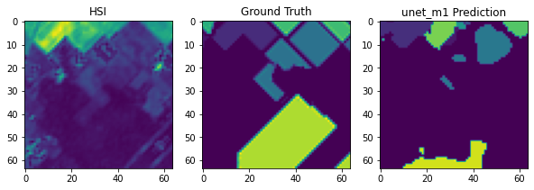

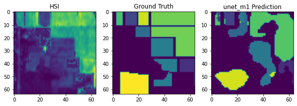

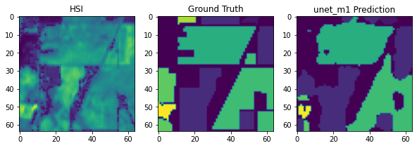

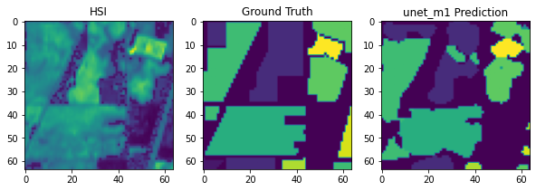

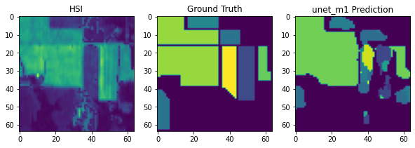

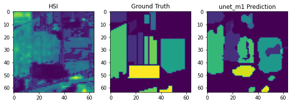

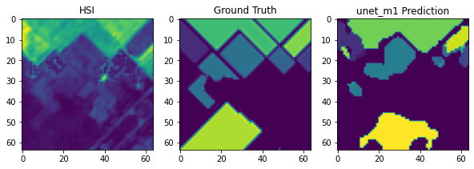

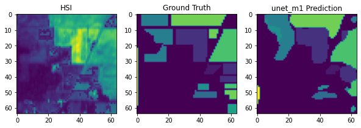

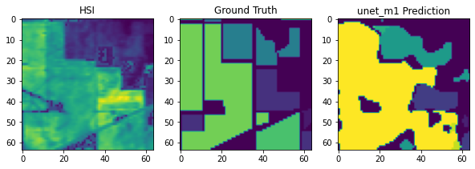

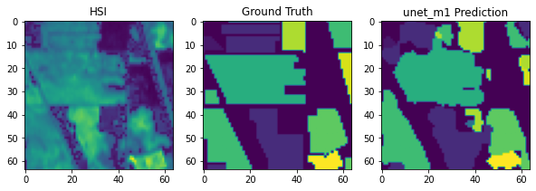

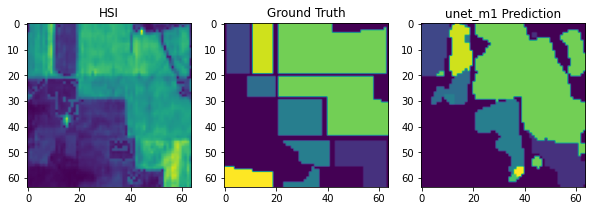

```python
# Plotting Model prediction of segmentation alongside HSI and Ground Truth
i=0
for im, gt in zip(X_test[20:100],y_test[20:100]):

    # model prediction
    pred = unet_m1.predict(im[np.newaxis,:,:,:])

    # generating the image based on the max probability of particular class
    prediction = np.argmax(pred,axis=-1)

    # plotting HSI image vs ground truth vs prediction
    plt.figure(figsize=(10,6))
    plt.subplot(131)
    plt.imshow(im[:,:,20])
    plt.title('HSI')
    plt.subplot(132)
    plt.imshow(gt)
    plt.title('Ground Truth')
    plt.subplot(133)
    plt.imshow(prediction[0])
    plt.title('unet_m1 Prediction')
    plt.show()
    i+=1
    if(i>10):
        break
```

##### unet_m1 prediction for complete image

Generating the segmentation of original image (145x145) from patches

```python
HSI_orig_patch = img_patch_list_new[0]
HSI_orig_patch.shape
```

```
(10, 10, 64, 64, 95)
```

```python
# Loading data associated with the original image (145x145)
HSI_orig_dataset = []
for i in range(HSI_orig_patch.shape[0]):
  for j in range(HSI_orig_patch.shape[1]):
    single_patch = HSI_orig_patch[i][j]
    single_patch = Std_scaler.transform(single_patch.reshape(-1,single_patch.shape[-1])).reshape(single_patch.shape)
    HSI_orig_dataset.append(single_patch)
```

```python
# Converting original patch list to numpy array
HSI_orig_dataset = np.array(HSI_orig_dataset)
```

```python
HSI_orig_dataset.shape
```

```
(100, 64, 64, 95)
```

```python
# predicting for individual patch
pred  = unet_m1.predict(HSI_orig_dataset)
prediction = np.argmax(pred,axis=-1)
```

```python
pred.shape
```

```
(100, 64, 64, 17)
```

```python
# individual patch is combined to form a grid of patches
grid = 0
img_pred = np.zeros((10, 10, 64, 64))
for i in range(10):
  for j in range(10):
    img_pred[i][j] = prediction[grid]
    grid+=1
```

###### Unpatchified prediction

```python
# converting the predicted patches into complete image using unpatchify
HSI_orig_pred = patch.unpatchify(img_pred, (145,145))
```

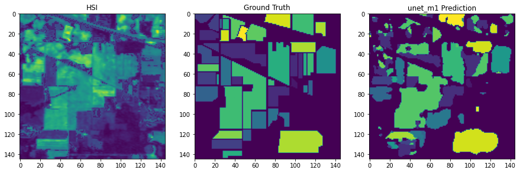

```python
# plottng comparison of HSI vs Ground truth vs unet_m1 predictions
plt.figure(figsize=(15,15))
plt.subplot(131)
plt.imshow(img[:,:,30])
plt.title('HSI')
plt.subplot(132)
plt.imshow(img_gt)
plt.title('Ground Truth')
plt.subplot(133)
plt.imshow(HSI_orig_pred)
plt.title('unet_m1 Prediction')
plt.show()
```

Note: In unpatchify method, each patch at the overlapping regions are replaced by next patch. Alternative approach for stitching all patches is presented below.

###### Prediction based on max score of patches

Here the segmentation is generated by constructing the matrix of size (145, 145, 100*17) where model prediction probablities(64x64x17) of each patch are placed along third axis in a manner mentioned below:

This is done to consider max probability from multiple prediction for the overlapping regions. In this way the best class is selected at overlapping regions by using argmax along third axis and modulo operator for 17

```python
# Generating the 3D probabilities grid of all patches associated with full image.
grid = 0
grp = 0
img_prediction = np.zeros((145, 145, 100*17))
for i in range(10):
  for j in range(10):
    img_prediction[i*9:i*9+64,
                   j*9:j*9+64,
                   grp:grp+17] = pred[grid]
    grid+=1
    grp+=17
```

```python
# Identifying the classes of each pixel from probabilities values of all patches corresponding to image(145x145)
prediction = np.argmax(img_prediction,axis=-1)%17
```

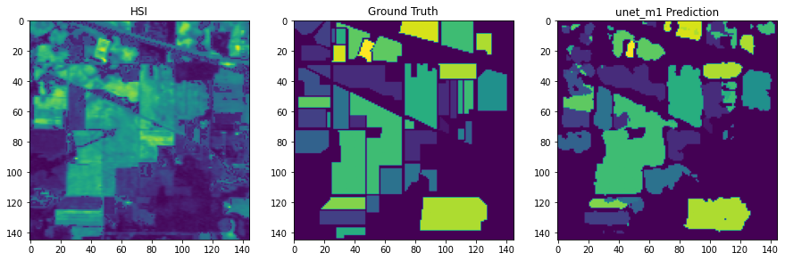

```python
# Plotting the segmentation after identifying the best class for overlapping patches
plt.figure(figsize=(15,15))
plt.subplot(131)
plt.imshow(img[:,:,30])
plt.title('HSI')
plt.subplot(132)
plt.imshow(img_gt)
plt.title('Ground Truth')
plt.subplot(133)
plt.imshow(prediction)
plt.title('unet_m1 Prediction')
plt.show()
```

We can observe that the segmentation is better than the unpatchify generated image.

##### Full image prediction score (F1 and kappa)

```python
# Flattening the ground truths and predictions (145x145 image) for score evaluation
y = img_gt.flatten()
y_hat = prediction.flatten()
```

```python
from sklearn.metrics import f1_score, cohen_kappa_score
```

```python
F1_unet_m1 = f1_score(y,y_hat,average='micro')
print('micro F1 score of pretrained unet model for full image : ',F1_unet_m1)
kappa_unet_m1 = cohen_kappa_score(y,y_hat)
print('kappa score of pretrained unet model for full image : ',kappa_unet_m1)
```

```
micro F1 score of pretrained unet model for full image :  0.8661117717003567
kappa score of pretrained unet model for full image :  0.8029087034442279
```

##### Validation set score

Score evaluation for the test split to understand the performance of predicting the patches

```python
X_test.shape,y_test.shape
```

```
((200, 64, 64, 95), (200, 64, 64))
```

```python
pred_test  = unet_m1.predict(X_test)
prediction_test = np.argmax(pred_test,axis=-1)
```

```python
prediction_test.shape
```

```
(200, 64, 64)
```

```python
# Flattening the prediction of validation/test set
y_val = y_test.flatten()
y_hat_val = prediction_test.flatten()
```

```python
F1_unet_m1_val = f1_score(y_val,y_hat_val,average='micro')
print('micro F1 score of pretrained unet model for validation data: ',F1_unet_m1_val)
kappa_unet_m1_val = cohen_kappa_score(y_val,y_hat_val)
print('kappa score of pretrained unet model for validation data: ',kappa_unet_m1_val)
```

```
micro F1 score of pretrained unet model for validation data:  0.72689453125
kappa score of pretrained unet model for validation data:  0.6315991067893165
```

```python
# plt.figure(figsize=(15,15))
# im_count=1
# for i in range(10):
#   for j in range(10):
#     plt.subplot(10,10,im_count)
#     plt.imshow(img_pred[i][j])
#     im_count+=1
# plt.show()
```

#### Model 2 - Simple Unet

Here neither backbones nor pretrained weights are considered for Network architecture. Basic Unet model is constructed and trained from scratch for Indian Pines HSI data.

- The Encoder section of the network have convolutions with same padding settings and 3 levels of max pooling.
- The Decoder section of the has 3 levels of upconvolution operation where the upconv output are combined with the conv operation outputs of Encoder section.
- Output of Decoder network is passed through two stages of convolutions where final output is probabilities for 17 classes(64x64x17)

##### Model Definition

```python
def simple_Unet(in_size,classes):
  '''This Function Generate and Returns Basic Unet model '''
  input = Input(in_size)

  #Encoder Section
  Enc_L1 = Conv2D(filters = 64, kernel_size = (3,3), padding='same', activation='relu',kernel_initializer='he_normal')(input)
  Enc_L1 = Conv2D(filters = 64, kernel_size = (3,3), padding='same', activation='relu',kernel_initializer='he_normal')(Enc_L1)
  Enc_P1 = MaxPooling2D(pool_size=(2, 2))(Enc_L1)

  Enc_L2 = Conv2D(filters = 128, kernel_size = (3,3), padding='same', activation='relu',kernel_initializer='he_normal')(Enc_P1)
  Enc_L2 = Conv2D(filters = 128, kernel_size = (3,3), padding='same', activation='relu',kernel_initializer='he_normal')(Enc_L2)
  Enc_P2 = MaxPooling2D(pool_size=(2, 2))(Enc_L2)

  Enc_L3 = Conv2D(filters = 256, kernel_size = (3,3), padding='same', activation='relu',kernel_initializer='he_normal')(Enc_P2)
  Enc_L3 = Conv2D(filters = 256, kernel_size = (3,3), padding='same', activation='relu',kernel_initializer='he_normal')(Enc_L3)
  Enc_P3 = MaxPooling2D(pool_size=(2, 2))(Enc_L3)

  Enc_L4 = Conv2D(filters = 512, kernel_size = (3,3), padding='same', activation='relu',kernel_initializer='he_normal')(Enc_P3)
  Enc_L4 = Conv2D(filters = 512, kernel_size = (3,3), padding='same', activation='relu',kernel_initializer='he_normal')(Enc_L4)
  # Enc_P4 = MaxPooling2D(pool_size=(2, 2))(Enc_L4)

  # Enc_L5 = Conv2D(filters = 1024, kernel_size = (3,3), padding='same', activation='relu',kernel_initializer='he_normal')(Enc_P4)
  # Enc_L5 = Conv2D(filters = 1024, kernel_size = (3,3), padding='same', activation='relu',kernel_initializer='he_normal')(Enc_L5)

  # Dec_L0 = Conv2DTranspose(filters = 512, kernel_size = (2,2), strides =(2,2), padding='valid')(Enc_L5)
  # Dec_L0 = concatenate([Dec_L0,Enc_L4])
  # Dec_L0 = Conv2D(filters = 256, kernel_size = (3,3), padding='same', activation='relu',kernel_initializer='he_normal')(Dec_L0)

  # Decoder Section
  Dec_L1 = Conv2DTranspose(filters = 256, kernel_size = (2,2), strides =(2,2), padding='valid')(Enc_L4)
  Dec_L1 = concatenate([Dec_L1,Enc_L3])
  Dec_L1 = Conv2D(filters = 256, kernel_size = (3,3), padding='same', activation='relu',kernel_initializer='he_normal')(Dec_L1)

  Dec_L2 = Conv2DTranspose(filters = 128, kernel_size = (2,2), strides =(2,2), padding='valid')(Dec_L1)
  Dec_L2 = concatenate([Dec_L2,Enc_L2])
  Dec_L2 = Conv2D(filters = 128, kernel_size = (3,3), padding='same', activation='relu',kernel_initializer='he_normal')(Dec_L2)

  Dec_L3 = Conv2DTranspose(filters = 64, kernel_size = (2,2), strides =(2,2), padding='valid')(Dec_L2)
  Dec_L3 = concatenate([Dec_L3,Enc_L1])
  Dec_L3 = Conv2D(filters = 64, kernel_size = (3,3), padding='same', activation='relu',kernel_initializer='he_normal')(Dec_L3)

  Dec_L4 = Conv2D(filters = 32, kernel_size = (3,3), padding='same', activation='relu',kernel_initializer='he_normal')(Dec_L3)

  Output = Conv2D(filters = classes, kernel_size = (1,1), activation='softmax')(Dec_L4)

  model = Model(inputs=input, outputs = Output)

  return model
```

```python
# del unet_m2
```

```python
unet_m2 = simple_Unet((64,64,95),17)
```

```python
unet_m2.summary()
```

```
Model: "model_2"
__________________________________________________________________________________________________
 Layer (type)                   Output Shape         Param #     Connected to
==================================================================================================
 input_2 (InputLayer)           [(None, 64, 64, 95)  0           []
                                ]

 conv2d_5 (Conv2D)              (None, 64, 64, 64)   54784       ['input_2[0][0]']

 conv2d_6 (Conv2D)              (None, 64, 64, 64)   36928       ['conv2d_5[0][0]']

 max_pooling2d (MaxPooling2D)   (None, 32, 32, 64)   0           ['conv2d_6[0][0]']

 conv2d_7 (Conv2D)              (None, 32, 32, 128)  73856       ['max_pooling2d[0][0]']

 conv2d_8 (Conv2D)              (None, 32, 32, 128)  147584      ['conv2d_7[0][0]']

 max_pooling2d_1 (MaxPooling2D)  (None, 16, 16, 128)  0          ['conv2d_8[0][0]']

 conv2d_9 (Conv2D)              (None, 16, 16, 256)  295168      ['max_pooling2d_1[0][0]']

 conv2d_10 (Conv2D)             (None, 16, 16, 256)  590080      ['conv2d_9[0][0]']

 max_pooling2d_2 (MaxPooling2D)  (None, 8, 8, 256)   0           ['conv2d_10[0][0]']

 conv2d_11 (Conv2D)             (None, 8, 8, 512)    1180160     ['max_pooling2d_2[0][0]']

 conv2d_12 (Conv2D)             (None, 8, 8, 512)    2359808     ['conv2d_11[0][0]']

 conv2d_transpose (Conv2DTransp  (None, 16, 16, 256)  524544     ['conv2d_12[0][0]']
 ose)

 concatenate (Concatenate)      (None, 16, 16, 512)  0           ['conv2d_transpose[0][0]',
                                                                  'conv2d_10[0][0]']

 conv2d_13 (Conv2D)             (None, 16, 16, 256)  1179904     ['concatenate[0][0]']

 conv2d_transpose_1 (Conv2DTran  (None, 32, 32, 128)  131200     ['conv2d_13[0][0]']
 spose)

 concatenate_1 (Concatenate)    (None, 32, 32, 256)  0           ['conv2d_transpose_1[0][0]',
                                                                  'conv2d_8[0][0]']

 conv2d_14 (Conv2D)             (None, 32, 32, 128)  295040      ['concatenate_1[0][0]']

 conv2d_transpose_2 (Conv2DTran  (None, 64, 64, 64)  32832       ['conv2d_14[0][0]']
 spose)

 concatenate_2 (Concatenate)    (None, 64, 64, 128)  0           ['conv2d_transpose_2[0][0]',
                                                                  'conv2d_6[0][0]']

 conv2d_15 (Conv2D)             (None, 64, 64, 64)   73792       ['concatenate_2[0][0]']

 conv2d_16 (Conv2D)             (None, 64, 64, 32)   18464       ['conv2d_15[0][0]']

 conv2d_17 (Conv2D)             (None, 64, 64, 17)   561         ['conv2d_16[0][0]']

==================================================================================================
Total params: 6,994,705
Trainable params: 6,994,705
Non-trainable params: 0
__________________________________________________________________________________________________
```

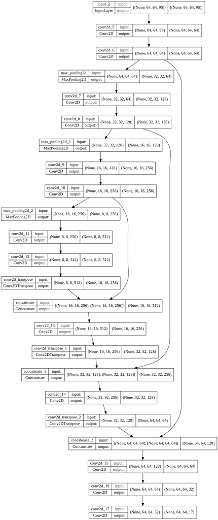

```python
tf.keras.utils.plot_model(unet_m2, to_file='unet_m2.png', show_shapes=True, show_layer_names=True,
                          rankdir='TB')
```

##### Model Compile

```python
optim = tf.keras.optimizers.Adam(0.0001)

focal_loss = sm.losses.cce_dice_loss #cce_dice_loss = categorical_crossentropy + dice_loss

unet_m2.compile(optim, focal_loss, metrics=[iou_score])
```

##### Model Training

Epoch 2/50 80/80 [==============================] - ETA: 0s - loss: 0.8011 - iou_score: 0.2067 Epoch 2: saving model to model_2_save/unet_m2_best_model_e02.h5 80/80 [==============================] - 9s 114ms/step - loss: 0.8011 - iou_score: 0.2067 - val_loss: 0.7253 - val_iou_score: 0.2675 - lr: 1.0000e-04

Epoch 3/50 80/80 [==============================] - ETA: 0s - loss: 0.6608 - iou_score: 0.3145 Epoch 3: saving model to model_2_save/unet_m2_best_model_e03.h5 80/80 [==============================] - 9s 113ms/step - loss: 0.6608 - iou_score: 0.3145 - val_loss: 0.6093 - val_iou_score: 0.3549 - lr: 1.0000e-04

Epoch 4/50 80/80 [==============================] - ETA: 0s - loss: 0.5768 - iou_score: 0.3834 Epoch 4: saving model to model_2_save/unet_m2_best_model_e04.h5 80/80 [==============================] - 9s 113ms/step - loss: 0.5768 - iou_score: 0.3834 - val_loss: 0.5627 - val_iou_score: 0.3929 - lr: 1.0000e-04

Epoch 5/50 80/80 [==============================] - ETA: 0s - loss: 0.4930 - iou_score: 0.4503 Epoch 5: saving model to model_2_save/unet_m2_best_model_e05.h5 80/80 [==============================] - 9s 112ms/step - loss: 0.4930 - iou_score: 0.4503 - val_loss: 0.4639 - val_iou_score: 0.4786 - lr: 1.0000e-04

Epoch 6/50 80/80 [==============================] - ETA: 0s - loss: 0.4403 - iou_score: 0.4991 Epoch 6: saving model to model_2_save/unet_m2_best_model_e06.h5

Epoch 6: ReduceLROnPlateau reducing learning rate to 8.999999772640876e-05. 80/80 [==============================] - 9s 113ms/step - loss: 0.4403 - iou_score: 0.4991 - val_loss: 0.4264 - val_iou_score: 0.5095 - lr: 1.0000e-04

Epoch 7/50 80/80 [==============================] - ETA: 0s - loss: 0.4070 - iou_score: 0.5302 Epoch 7: saving model to model_2_save/unet_m2_best_model_e07.h5 80/80 [==============================] - 9s 113ms/step - loss: 0.4070 - iou_score: 0.5302 - val_loss: 0.3880 - val_iou_score: 0.5482 - lr: 9.0000e-05

Epoch 8/50 80/80 [==============================] - ETA: 0s - loss: 0.3784 - iou_score: 0.5588 Epoch 8: saving model to model_2_save/unet_m2_best_model_e08.h5 80/80 [==============================] - 9s 113ms/step - loss: 0.3784 - iou_score: 0.5588 - val_loss: 0.3646 - val_iou_score: 0.5744 - lr: 9.0000e-05

Epoch 9/50 80/80 [==============================] - ETA: 0s - loss: 0.3539 - iou_score: 0.5845 Epoch 9: saving model to model_2_save/unet_m2_best_model_e09.h5 80/80 [==============================] - 9s 115ms/step - loss: 0.3539 - iou_score: 0.5845 - val_loss: 0.3433 - val_iou_score: 0.5932 - lr: 9.0000e-05

Epoch 10/50 80/80 [==============================] - ETA: 0s - loss: 0.3415 - iou_score: 0.5971 Epoch 10: saving model to model_2_save/unet_m2_best_model_e10.h5 80/80 [==============================] - 9s 113ms/step - loss: 0.3415 - iou_score: 0.5971 - val_loss: 0.3340 - val_iou_score: 0.6023 - lr: 9.0000e-05

Epoch 11/50 80/80 [==============================] - ETA: 0s - loss: 0.3265 - iou_score: 0.6129 Epoch 11: saving model to model_2_save/unet_m2_best_model_e11.h5

Epoch 11: ReduceLROnPlateau reducing learning rate to 8.100000122794882e-05. 80/80 [==============================] - 9s 113ms/step - loss: 0.3265 - iou_score: 0.6129 - val_loss: 0.3207 - val_iou_score: 0.6170 - lr: 9.0000e-05

Epoch 12/50 80/80 [==============================] - ETA: 0s - loss: 0.3142 - iou_score: 0.6264 Epoch 12: saving model to model_2_save/unet_m2_best_model_e12.h5 80/80 [==============================] - 9s 113ms/step - loss: 0.3142 - iou_score: 0.6264 - val_loss: 0.3070 - val_iou_score: 0.6322 - lr: 8.1000e-05

Epoch 13/50 80/80 [==============================] - ETA: 0s - loss: 0.3065 - iou_score: 0.6346 Epoch 13: saving model to model_2_save/unet_m2_best_model_e13.h5 80/80 [==============================] - 9s 113ms/step - loss: 0.3065 - iou_score: 0.6346 - val_loss: 0.3042 - val_iou_score: 0.6313 - lr: 8.1000e-05

Epoch 14/50 80/80 [==============================] - ETA: 0s - loss: 0.2994 - iou_score: 0.6413 Epoch 14: saving model to model_2_save/unet_m2_best_model_e14.h5 80/80 [==============================] - 9s 115ms/step - loss: 0.2994 - iou_score: 0.6413 - val_loss: 0.2952 - val_iou_score: 0.6447 - lr: 8.1000e-05

Epoch 15/50 80/80 [==============================] - ETA: 0s - loss: 0.2935 - iou_score: 0.6470 Epoch 15: saving model to model_2_save/unet_m2_best_model_e15.h5 80/80 [==============================] - 9s 113ms/step - loss: 0.2935 - iou_score: 0.6470 - val_loss: 0.2932 - val_iou_score: 0.6458 - lr: 8.1000e-05

Epoch 16/50 80/80 [==============================] - ETA: 0s - loss: 0.2847 - iou_score: 0.6564 Epoch 16: saving model to model_2_save/unet_m2_best_model_e16.h5

Epoch 16: ReduceLROnPlateau reducing learning rate to 7.289999848580919e-05. 80/80 [==============================] - 9s 113ms/step - loss: 0.2847 - iou_score: 0.6564 - val_loss: 0.2814 - val_iou_score: 0.6580 - lr: 8.1000e-05

Epoch 17/50 80/80 [==============================] - ETA: 0s - loss: 0.2757 - iou_score: 0.6642 Epoch 17: saving model to model_2_save/unet_m2_best_model_e17.h5 80/80 [==============================] - 10s 121ms/step - loss: 0.2757 - iou_score: 0.6642 - val_loss: 0.2719 - val_iou_score: 0.6657 - lr: 7.2900e-05

Epoch 18/50 80/80 [==============================] - ETA: 0s - loss: 0.2648 - iou_score: 0.6730 Epoch 18: saving model to model_2_save/unet_m2_best_model_e18.h5 80/80 [==============================] - 11s 138ms/step - loss: 0.2648 - iou_score: 0.6730 - val_loss: 0.2661 - val_iou_score: 0.6704 - lr: 7.2900e-05

Epoch 19/50 80/80 [==============================] - ETA: 0s - loss: 0.2529 - iou_score: 0.6839 Epoch 19: saving model to model_2_save/unet_m2_best_model_e19.h5 80/80 [==============================] - 10s 126ms/step - loss: 0.2529 - iou_score: 0.6839 - val_loss: 0.2514 - val_iou_score: 0.6851 - lr: 7.2900e-05

Epoch 20/50 80/80 [==============================] - ETA: 0s - loss: 0.2433 - iou_score: 0.6931 Epoch 20: saving model to model_2_save/unet_m2_best_model_e20.h5 80/80 [==============================] - 9s 114ms/step - loss: 0.2433 - iou_score: 0.6931 - val_loss: 0.2530 - val_iou_score: 0.6822 - lr: 7.2900e-05

Epoch 21/50 80/80 [==============================] - ETA: 0s - loss: 0.2419 - iou_score: 0.6942 Epoch 21: saving model to model_2_save/unet_m2_best_model_e21.h5

Epoch 21: ReduceLROnPlateau reducing learning rate to 6.56100019114092e-05. 80/80 [==============================] - 10s 121ms/step - loss: 0.2419 - iou_score: 0.6942 - val_loss: 0.2478 - val_iou_score: 0.6889 - lr: 7.2900e-05

Epoch 22/50 80/80 [==============================] - ETA: 0s - loss: 0.2297 - iou_score: 0.7072 Epoch 22: saving model to model_2_save/unet_m2_best_model_e22.h5 80/80 [==============================] - 10s 123ms/step - loss: 0.2297 - iou_score: 0.7072 - val_loss: 0.2326 - val_iou_score: 0.7055 - lr: 6.5610e-05

Epoch 23/50 80/80 [==============================] - ETA: 0s - loss: 0.2204 - iou_score: 0.7168 Epoch 23: saving model to model_2_save/unet_m2_best_model_e23.h5 80/80 [==============================] - 9s 116ms/step - loss: 0.2204 - iou_score: 0.7168 - val_loss: 0.2456 - val_iou_score: 0.6902 - lr: 6.5610e-05

Epoch 24/50 80/80 [==============================] - ETA: 0s - loss: 0.2188 - iou_score: 0.7181 Epoch 24: saving model to model_2_save/unet_m2_best_model_e24.h5 80/80 [==============================] - 10s 126ms/step - loss: 0.2188 - iou_score: 0.7181 - val_loss: 0.2221 - val_iou_score: 0.7147 - lr: 6. 5610e-05

Epoch 25/50 80/80 [==============================] - ETA: 0s - loss: 0.2090 - iou_score: 0.7299 Epoch 25: saving model to model_2_save/unet_m2_best_model_e25.h5 80/80 [==============================] - 9s 114ms/step - loss: 0.2090 - iou_score: 0.7299 - val_loss: 0.2203 - val_iou_score: 0.7207 - lr: 6.5610e-05

Epoch 26/50 80/80 [==============================] - ETA: 0s - loss: 0.2086 - iou_score: 0.7298 Epoch 26: saving model to model_2_save/unet_m2_best_model_e26.h5

Epoch 26: ReduceLROnPlateau reducing learning rate to 5.904900172026828e-05. 80/80 [==============================] - 9s 113ms/step - loss: 0.2086 - iou_score: 0.7298 - val_loss: 0.2257 - val_iou_score: 0.7110 - lr: 6.5610e-05

Epoch 27/50 80/80 [==============================] - ETA: 0s - loss: 0.2040 - iou_score: 0.7349 Epoch 27: saving model to model_2_save/unet_m2_best_model_e27.h5 80/80 [==============================] - 10s 126ms/step - loss: 0.2040 - iou_score: 0.7349 - val_loss: 0.2161 - val_iou_score: 0.7232 - lr: 5.9049e-05

Epoch 28/50 80/80 [==============================] - ETA: 0s - loss: 0.1983 - iou_score: 0.7415

Epoch 28: saving model to model_2_save/unet_m2_best_model_e28.h5 80/80 [==============================] - 12s 149ms/step - loss: 0.1983 - iou_score: 0.7415 - val_loss: 0.2173 - val_iou_score: 0.7209 - lr: 5.9049e-05

Epoch 29/50 80/80 [==============================] - ETA: 0s - loss: 0.1947 - iou_score: 0.7456 Epoch 29: saving model to model_2_save/unet_m2_best_model_e29.h5 80/80 [==============================] - 9s 115ms/step - loss: 0.1947 - iou_score: 0.7456 - val_loss: 0.2065 - val_iou_score: 0.7346 - lr: 5.9049e-05

Epoch 30/50 80/80 [==============================] - ETA: 0s - loss: 0.1910 - iou_score: 0.7499 Epoch 30: saving model to model_2_save/unet_m2_best_model_e30.h5 80/80 [==============================] - 9s 115ms/step - loss: 0.1910 - iou_score: 0.7499 - val_loss: 0.2086 - val_iou_score: 0.7322 - lr: 5.9049e-05

Epoch 31/50 80/80 [==============================] - ETA: 0s - loss: 0.1888 - iou_score: 0.7519 Epoch 31: saving model to model_2_save/unet_m2_best_model_e31.h5

Epoch 31: ReduceLROnPlateau reducing learning rate to 5.314410154824145e-05. 80/80 [==============================] - 9s 115ms/step - loss: 0.1888 - iou_score: 0.7519 - val_loss: 0.2149 - val_iou_score: 0.7213 - lr: 5.9049e-05

Epoch 32/50 80/80 [==============================] - ETA: 0s - loss: 0.1852 - iou_score: 0.7560 Epoch 32: saving model to model_2_save/unet_m2_best_model_e32.h5 80/80 [==============================] - 10s 121ms/step - loss: 0.1852 - iou_score: 0.7560 - val_loss: 0.1974 - val_iou_score: 0.7424 - lr: 5.3144e-05

Epoch 33/50 80/80 [==============================] - ETA: 0s - loss: 0.1791 - iou_score: 0.7633 Epoch 33: saving model to model_2_save/unet_m2_best_model_e33.h5 80/80 [==============================] - 12s 147ms/step - loss: 0.1791 - iou_score: 0.7633 - val_loss: 0.1910 - val_iou_score: 0.7502 - lr: 5.3144e-05

Epoch 34/50 80/80 [==============================] - ETA: 0s - loss: 0.1755 - iou_score: 0.7675 Epoch 34: saving model to model_2_save/unet_m2_best_model_e34.h5 80/80 [==============================] - 9s 114ms/step - loss: 0.1755 - iou_score: 0.7675 - val_loss: 0.1929 - val_iou_score: 0.7483 - lr: 5.3144e-05

Epoch 35/50 80/80 [==============================] - ETA: 0s - loss: 0.1709 - iou_score: 0.7727 Epoch 35: saving model to model_2_save/unet_m2_best_model_e35.h5 80/80 [==============================] - 9s 114ms/step - loss: 0.1709 - iou_score: 0.7727 - val_loss: 0.1869 - val_iou_score: 0.7556 - lr: 5.3144e-05

Epoch 36/50 80/80 [==============================] - ETA: 0s - loss: 0.1684 - iou_score: 0.7757 Epoch 36: saving model to model_2_save/unet_m2_best_model_e36.h5

Epoch 36: ReduceLROnPlateau reducing learning rate to 4.7829690083744934e-05. 80/80 [==============================] - 9s 113ms/step - loss: 0.1684 - iou_score: 0.7757 - val_loss: 0.1860 - val_iou_score: 0.7575 - lr: 5.3144e-05

Epoch 37/50 80/80 [==============================] - ETA: 0s - loss: 0.1676 - iou_score: 0.7766 Epoch 37: saving model to model_2_save/unet_m2_best_model_e37.h5 80/80 [==============================] - 9s 114ms/step - loss: 0.1676 - iou_score: 0.7766 - val_loss: 0.1872 - val_iou_score: 0.7563 - lr: 4.7830e-05

Epoch 38/50 80/80 [==============================] - ETA: 0s - loss: 0.1624 - iou_score: 0.7827 Epoch 38: saving model to model_2_save/unet_m2_best_model_e38.h5 80/80 [==============================] - 10s 124ms/step - loss: 0.1624 - iou_score: 0.7827 - val_loss: 0.1805 - val_iou_score: 0.7627 - lr: 4.7830e-05

Epoch 39/50 80/80 [==============================] - ETA: 0s - loss: 0.1620 - iou_score: 0.7828 Epoch 39: saving model to model_2_save/unet_m2_best_model_e39.h5 80/80 [==============================] - 10s 130ms/step - loss: 0.1620 - iou_score: 0.7828 - val_loss: 0.1799 - val_iou_score: 0.7628 - lr: 4.7830e-05

Epoch 40/50 80/80 [==============================] - ETA: 0s - loss: 0.1601 - iou_score: 0.7849 Epoch 40: saving model to model_2_save/unet_m2_best_model_e40.h5 80/80 [==============================] - 9s 115ms/step - loss: 0.1601 - iou_score: 0.7849 - val_loss: 0.1764 - val_iou_score: 0.7669 - lr: 4.7830e-05

Epoch 41/50 80/80 [==============================] - ETA: 0s - loss: 0.1565 - iou_score: 0.7889 Epoch 41: saving model to model_2_save/unet_m2_best_model_e41.h5

Epoch 41: ReduceLROnPlateau reducing learning rate to 4.304672074795235e-05. 80/80 [==============================] - 9s 113ms/step - loss: 0.1565 - iou_score: 0.7889 - val_loss: 0.1782 - val_iou_score: 0.7654 - lr: 4.7830e-05

Epoch 42/50 80/80 [==============================] - ETA: 0s - loss: 0.1529 - iou_score: 0.7935 Epoch 42: saving model to model_2_save/unet_m2_best_model_e42.h5 80/80 [==============================] - 9s 112ms/step - loss: 0.1529 - iou_score: 0.7935 - val_loss: 0.1740 - val_iou_score: 0.7698 - lr: 4.3047e-05

Epoch 43/50 80/80 [==============================] - ETA: 0s - loss: 0.1498 - iou_score: 0.7971 Epoch 43: saving model to model_2_save/unet_m2_best_model_e43.h5 80/80 [==============================] - 9s 113ms/step - loss: 0.1498 - iou_score: 0.7971 - val_loss: 0.1719 - val_iou_score: 0.7713 - lr: 4.3047e-05

Epoch 44/50 80/80 [==============================] - ETA: 0s - loss: 0.1470 - iou_score: 0.8005 Epoch 44: saving model to model_2_save/unet_m2_best_model_e44.h5 80/80 [==============================] - 9s 113ms/step - loss: 0.1470 - iou_score: 0.8005 - val_loss: 0.1727 - val_iou_score: 0.7720 - lr: 4.3047e-05

Epoch 45/50 80/80 [==============================] - ETA: 0s - loss: 0.1463 - iou_score: 0.8012 Epoch 45: saving model to model_2_save/unet_m2_best_model_e45.h5 80/80 [==============================] - 9s 113ms/step - loss: 0.1463 - iou_score: 0.8012 - val_loss: 0.1718 - val_iou_score: 0.7736 - lr: 4.3047e-05

Epoch 46/50 80/80 [==============================] - ETA: 0s - loss: 0.1467 - iou_score: 0.8005 Epoch 46: saving model to model_2_save/unet_m2_best_model_e46.h5

Epoch 46: ReduceLROnPlateau reducing learning rate to 3.8742047036066654e-05. 80/80 [==============================] - 9s 113ms/step - loss: 0.1467 - iou_score: 0.8005 - val_loss: 0.1713 - val_iou_score: 0.7735 - lr: 4.3047e-05

Epoch 47/50 80/80 [==============================] - ETA: 0s - loss: 0.1435 - iou_score: 0.8045 Epoch 47: saving model to model_2_save/unet_m2_best_model_e47.h5 80/80 [==============================] - 9s 113ms/step - loss: 0.1435 - iou_score: 0.8045 - val_loss: 0.1673 - val_iou_score: 0.7771 - lr: 3.8742e-05

Epoch 48/50 80/80 [==============================] - ETA: 0s - loss: 0.1429 - iou_score: 0.8053 Epoch 48: saving model to model_2_save/unet_m2_best_model_e48.h5 80/80 [==============================] - 9s 113ms/step - loss: 0.1429 - iou_score: 0.8053 - val_loss: 0.1670 - val_iou_score: 0.7791 - lr: 3.8742e-05

Epoch 49/50 80/80 [==============================] - ETA: 0s - loss: 0.1386 - iou_score: 0.8108 Epoch 49: saving model to model_2_save/unet_m2_best_model_e49.h5 80/80 [==============================] - 9s 113ms/step - loss: 0.1386 - iou_score: 0.8108 - val_loss: 0.1668 - val_iou_score: 0.7793 - lr: 3.8742e-05

Epoch 50/50 80/80 [==============================] - ETA: 0s - loss: 0.1366 - iou_score: 0.8132 Epoch 50: saving model to model_2_save/unet_m2_best_model_e50.h5 80/80 [==============================] - 9s 113ms/step - loss: 0.1366 - iou_score: 0.8132 - val_loss: 0.1647 - val_iou_score: 0.7814 - lr: 3.8742e-05 Time Taken for training (sec): 502.0929501056671

```python
# loading model weights from 50th epoch
unet_m2.load_weights('/content/model_2_save/unet_m2_best_model_e50.h5')
```

```python
#lr 3.8742e-05 at 50 epoch
optim = tf.keras.optimizers.Adam(3.8742e-05)

focal_loss = sm.losses.cce_dice_loss #cce_dice_loss = categorical_crossentropy + dice_loss

unet_m2.compile(optim, focal_loss, metrics=[iou_score])
```

```python
datetime_stamp = datetime.now().strftime("%Y%m%d-%H%M%S")
logdir = os.path.join("logs", datetime_stamp)
print(datetime_stamp)
# tensorboard = TensorBoard(log_dir=logdir)
tensorboard = TensorBoard(log_dir=logdir, histogram_freq=1, write_graph=True,write_grads=True)

checkpoint_m2 = ModelCheckpoint('model_2_save2/unet_m2_best_model_e50+{epoch:02d}.h5',
                                save_weights_only=True, save_best_only=True,mode ='max',
                                monitor='val_iou_score',verbose=1)

Reduce_LR_m2 = ReduceLROnPlateau(monitor='val_iou_score', factor = 0.9, min_lr=0.00001,patience=5,verbose=1)

callbacks_m2 = [checkpoint_m2, Reduce_LR_m2, tensorboard]

start = time.time()
history_m2 = unet_m2.fit_generator(train_dataloader,
                                   steps_per_epoch=len(train_dataloader),
                                   epochs=50,
                                   validation_data=test_dataloader,
                                   callbacks=callbacks_m2)

stop = time.time()
print('Time Taken for training (sec): ',stop-start)
```

```
20220303-121410
WARNING:tensorflow:`write_grads` will be ignored in TensorFlow 2.0 for the `TensorBoard` Callback.
```

```
Epoch 1: val_iou_score improved from -inf to 0.78607, saving model to model_2_save2/unet_m2_best_model_e50+01.h5
Epoch 2: val_iou_score did not improve from 0.78607
Epoch 3: val_iou_score improved from 0.78607 to 0.78641, saving model to model_2_save2/unet_m2_best_model_e50+03.h5
Epoch 4: val_iou_score improved from 0.78641 to 0.78679, saving model to model_2_save2/unet_m2_best_model_e50+04.h5
Epoch 5: val_iou_score improved from 0.78679 to 0.78842, saving model to model_2_save2/unet_m2_best_model_e50+05.h5
Epoch 6: val_iou_score improved from 0.78842 to 0.79251, saving model to model_2_save2/unet_m2_best_model_e50+06.h5
Epoch 7: val_iou_score did not improve from 0.79251

Epoch 7: ReduceLROnPlateau reducing learning rate to 3.486780042294413e-05.
Epoch 8: val_iou_score did not improve from 0.79251
Epoch 9: val_iou_score improved from 0.79251 to 0.79252, saving model to model_2_save2/unet_m2_best_model_e50+09.h5
Epoch 10: val_iou_score improved from 0.79252 to 0.79668, saving model to model_2_save2/unet_m2_best_model_e50+10.h5
Epoch 11: val_iou_score did not improve from 0.79668
Epoch 12: val_iou_score did not improve from 0.79668

Epoch 12: ReduceLROnPlateau reducing learning rate to 3.138102038064972e-05.
Epoch 13: val_iou_score improved from 0.79668 to 0.80021, saving model to model_2_save2/unet_m2_best_model_e50+13.h5
Epoch 14: val_iou_score did not improve from 0.80021
Epoch 15: val_iou_score did not improve from 0.80021
Epoch 16: val_iou_score improved from 0.80021 to 0.80176, saving model to model_2_save2/unet_m2_best_model_e50+16.h5
Epoch 17: val_iou_score did not improve from 0.80176

Epoch 17: ReduceLROnPlateau reducing learning rate to 2.824291768774856e-05.
Epoch 18: val_iou_score improved from 0.80176 to 0.80417, saving model to model_2_save2/unet_m2_best_model_e50+18.h5
Epoch 19: val_iou_score did not improve from 0.80417
Epoch 20: val_iou_score improved from 0.80417 to 0.80552, saving model to model_2_save2/unet_m2_best_model_e50+20.h5
Epoch 21: val_iou_score improved from 0.80552 to 0.80670, saving model to model_2_save2/unet_m2_best_model_e50+21.h5
Epoch 22: val_iou_score improved from 0.80670 to 0.80834, saving model to model_2_save2/unet_m2_best_model_e50+22.h5

Epoch 22: ReduceLROnPlateau reducing learning rate to 2.5418625591555612e-05.
Epoch 23: val_iou_score did not improve from 0.80834
Epoch 24: val_iou_score did not improve from 0.80834
Epoch 25: val_iou_score improved from 0.80834 to 0.80925, saving model to model_2_save2/unet_m2_best_model_e50+25.h5
Epoch 26: val_iou_score improved from 0.80925 to 0.80947, saving model to model_2_save2/unet_m2_best_model_e50+26.h5
Epoch 27: val_iou_score did not improve from 0.80947

Epoch 27: ReduceLROnPlateau reducing learning rate to 2.2876762704981958e-05.
Epoch 28: val_iou_score improved from 0.80947 to 0.81058, saving model to model_2_save2/unet_m2_best_model_e50+28.h5
Epoch 29: val_iou_score did not improve from 0.81058
Epoch 30: val_iou_score improved from 0.81058 to 0.81273, saving model to model_2_save2/unet_m2_best_model_e50+30.h5
```

[output cut: 14 more lines]

```
Epoch 41: val_iou_score did not improve from 0.81655
Epoch 42: val_iou_score did not improve from 0.81655

Epoch 42: ReduceLROnPlateau reducing learning rate to 1.667716005613329e-05.
Epoch 43: val_iou_score did not improve from 0.81655
Epoch 44: val_iou_score did not improve from 0.81655
Epoch 45: val_iou_score did not improve from 0.81655
Epoch 46: val_iou_score improved from 0.81655 to 0.81789, saving model to model_2_save2/unet_m2_best_model_e50+46.h5
Epoch 47: val_iou_score did not improve from 0.81789

Epoch 47: ReduceLROnPlateau reducing learning rate to 1.50094445416471e-05.
Epoch 48: val_iou_score improved from 0.81789 to 0.81807, saving model to model_2_save2/unet_m2_best_model_e50+48.h5
Epoch 49: val_iou_score improved from 0.81807 to 0.81936, saving model to model_2_save2/unet_m2_best_model_e50+49.h5
Epoch 50: val_iou_score did not improve from 0.81936
Time Taken for training (sec):  459.3442509174347
```

```python
# # http://localhost:6006/
%load_ext tensorboard
%tensorboard --logdir logs --host localhost
```

```python
# index of max iou_score
np.argmax(history_m2.history['val_iou_score'])
```

```
48
```